# Chicago Air Pollution and Mortality

May 7, 2021

# Introduction

Mortality has been found to be affected by a number of environmental factors, such as air pollution and extreme temperature. The objective of this study was to determine how air pollution may associated with daily mortality rate. Specifically, we wished to determine if 1) there was evidence that pollutants are associated with increased mortality, and if so, which had the strongest association, 2) whether the effect of pollutants was instantaneous or extended over time, and 3) the predicted mortality of a day with the lowest measurement of each kind of pollutant on a 70-degree day. The study used data measurements of median air pollutant content, mean temperature, and non-accidental deaths in Chicago, Illinois from 1987 to 2000, specifically focusing on particulate matter, ozone, and sulfur oxide. Each air pollutant also had measurements of its 7-day average.

# Exploratory Data Analysis

### Air Pollutants

We can visualize and compare the distributions of the three air pollutant variables of particulate matter (PM), ozone (O3), and sulfur oxide (SO2) with the side-by-side boxplots in Figure 1.

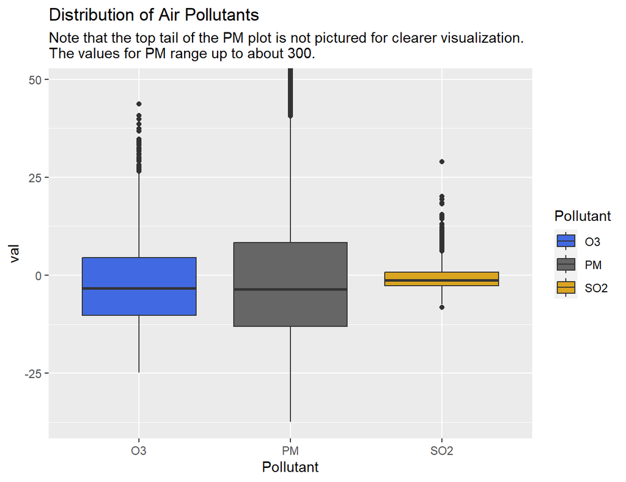

Boxplots of ozone, particulate matter, and sulfur oxide.

### Temperature

We visualize the distribution of the daily mean temperature values with a histogram in Figure 2.

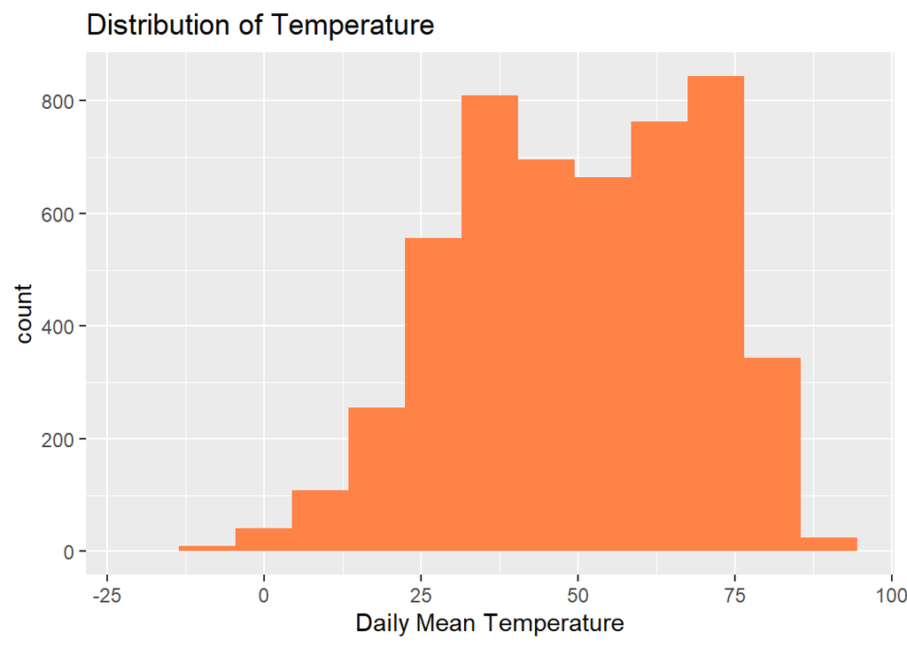

Histogram of daily mean temperature.

We might expect temperature to be symmetrical, but it appears to be slightly left-skewed (we will see why later on in the EDA) though mostly symmetrical. There are two peaks, one at about 35 degrees and another at about 70 degrees.

### Mortality

We intend to fit the data to a Poisson GAM regression model, meaning a logarithmic link function, so we use the log-transformation of the daily deaths measurement in our EDA. We visualize the distribution of the log-transformation in a histogram in Figure 3.

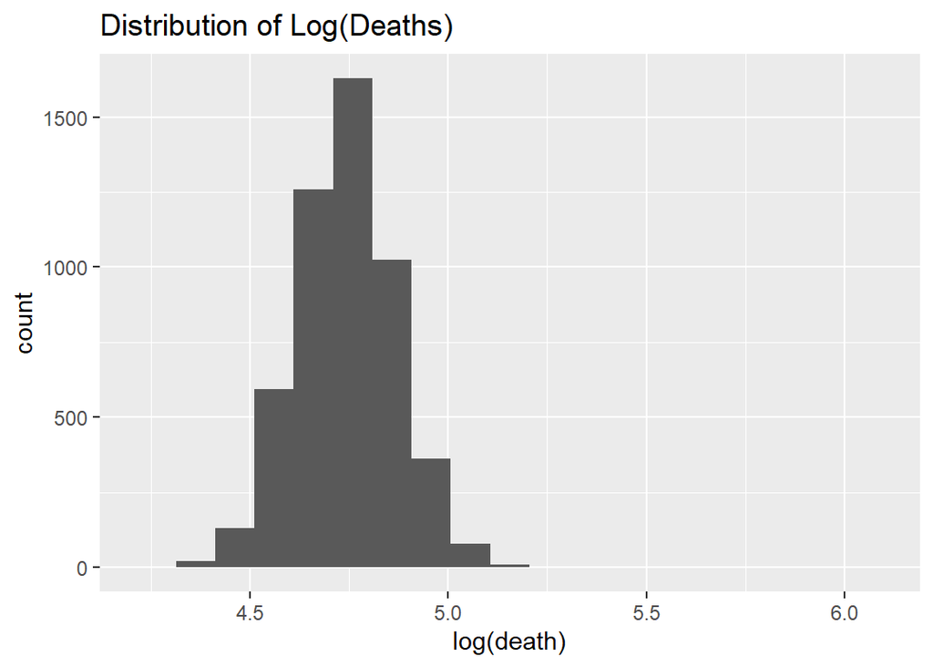

Histogram of Log(death).

The distribution appears symmetrical with some outliers in the upper extremity. What we are really interested in is the variable matches a Poisson distribution. We check this using Q-Q plots comparing the sample points of both the death variable and its log-transformation to a theoretical Poisson distribution (Figure 4).

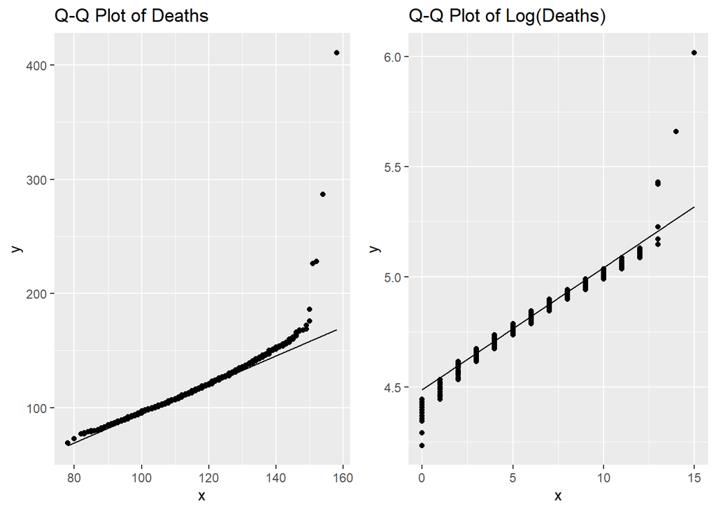

Poisson Q-Q plots of the death variable and its log-transformation.

We see that both plots adhere quite closely to a Poisson distribution, so our Poisson regression models can fit to the data. (2, 5)

### Multivariate EDA: Variables over Time

We plot the seasonal decompositions of each variable (non-lagged) to visualize their overall trends and seasonalities over time (Figure 5) and give insight into how they may relate to each other. NA data for each variable is not plotted on its respective graph.

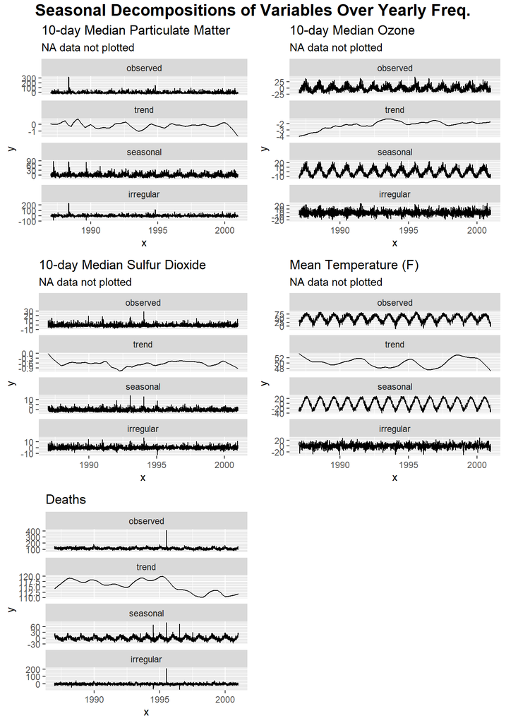

Seasonal decompositions of the variables.

We observe an outlier in deaths in mid-1995. This can be attributed to the July 1995 Chicago heat wave with a recorded 739 heat-related deaths over 5 days ([source](https://en.wikipedia.org/wiki/1995_Chicago_heat_wave)). The heat wave demonstrates that higher temperatures can contribute to higher mortality rate, so this outlier does not need to be omitted.

The overall trends for each variable are that deaths have been decreasing after a rise in 1995, particulate matter has not changed much until decreasing sharply in 2000, and ozone has been slowly increasing since 1985, temperature appears to have been decreasing over time, while sulfur does not show a strong overall trend. Ozone and tempreature show strong seasonality with clear sinusoidal patterns over the year: temperature is lowest at the beginning and end of the year (winter) and highest in the middle (summer), and ozone behaves similarly. Death also shows some seasonality; it appears to be higher at the beginning and end of the year, perhaps due to people succumbing to cold weather, but overall does not have as strong as a pattern as the temperature or ozone. Particulate matter and sulfur dioxide do not appear to have significant seasonal patterns. The seasonal decompositions for the lagged variables show the same trends and patterns and thus are omitted due to redundancy.

The EDA of the variables over time suggests that ozone and temperature will associate strongly with each other and that sulfur dioxide may not be a significant variable in our modeling.

### Multivariate EDA: Pairs

We can further confirm any correlations between the variables with a pairs plot (Figure 6) and correlation matrix (Table 1). (3, 4)

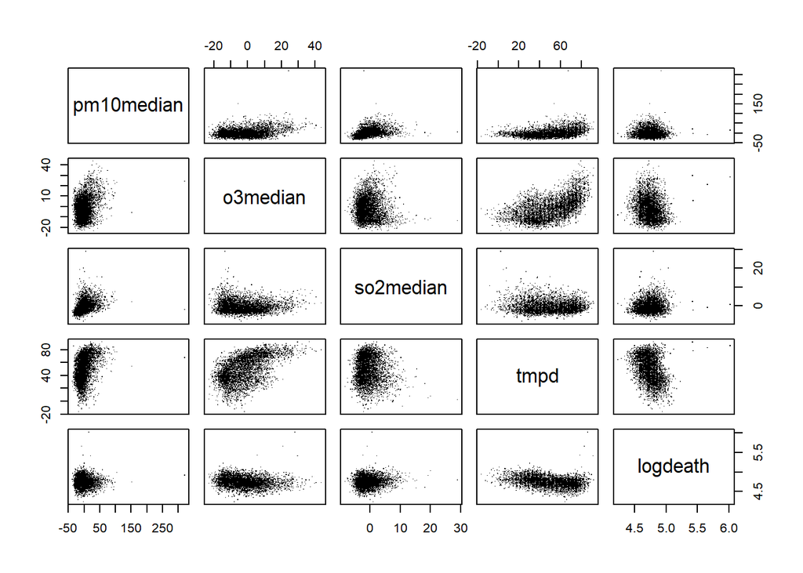

Pairs plot of the variables.

Correlation matrix of the variables.

|  | pm10median | o3median | so2median | tmpd | logdeath |
| --- | --- | --- | --- | --- | --- |
| pm10median | 1.0000000 | 0.2965487 | 0.4200137 | 0.3603820 | -0.0093874 |
| o3median | 0.2965487 | 1.0000000 | -0.0638283 | 0.5583430 | -0.1861099 |
| so2median | 0.4200137 | -0.0638283 | 1.0000000 | -0.0506693 | 0.1128019 |
| tmpd | 0.3603820 | 0.5583430 | -0.0506693 | 1.0000000 | -0.3841101 |
| logdeath | -0.0093874 | -0.1861099 | 0.1128019 | -0.3841101 | 1.0000000 |

The plot and table show us that the correlations between the variables are fairly low, especially with mortality; the highest correlation value for death is with temperature at about $-0.3841$. Of the air pollutants, correlation with death is highest with O3, then SO2, then PM. Some other correlations of note are between SO2 and PM ($0.4200$) and between temperature and O3 ($0.5583$). The correlation suggests that O3 may be the most significant air pollutant contributing to mortality .

# Modeling & Diagnostics

We begin by fitting two Poisson GAMs to the data, one using the non-lagged variables of daily mean or median measurements, the other using the lagged measurements of 7-day averages of each variable. A GAM linear predictor, link function, and dispersion scale function (we will primarily focus on the former two– essentially it’s a function that models the variance). Using the linear predictor and the Poisson’s canonical link function of the logarithm, our model is defined as

$$\log(\mu_i) = \beta_0 + r_1(x_{i1}) +
r_2(x_{i2}) + r_3(x_{i3}) + r_4(x_{i4}), \quad i = 1,\ldots
n$$

with each additive predictor regression function $r_p(x_{ip})$ corresponding to one of our covariates of PM, O3, SO2, and temperature (or its lagged version), and $i$ being one of $n$ data points. For our two models, we use smoother spline terms of 4 degrees of freedom for our regression functions.

Note that although we are ostensibly fitting a model to predict the death *rate*, suggesting that we may want to fit our Poisson regression with an offset, the rate is defined as deaths per day, which for this dataset corresponds to a single untransformed data point. No variable defines the exposure of the population. We therefore fit our Poisson GAM without an offset term, and our response variable remains as the prediction for the number of deaths on a single given day.

To compare the performance of the two models, we use 5-fold cross-validation and obtain the average mean squared error (MSE) and standard error (SE) from across each fold. The resulting error metrics are in Table 2.

5-fold CV errors of the two models.

|  | Non-Lag | Lagged |
| --- | --- | --- |
| MSE | 194.04549 | 187.32588 |
| SE | 21.31645 | 21.21002 |

The cross-validation of the two models yields a lower MSE on the lagged model and slightly lower SE for the lagged model. It’s possible that MSE for the lagged model happened to be lower on this particular cross-validation, but due to the highly similar standard errors, of which the lagged model’s is lower, we choose the lagged model as the more correct model.

# Results

We examine the global goodness-of-fit test of our lagged model using a chi-squared test. In a Poisson regression, the deviance residual $D$ of the model can be used to measure goodness-of-fit through comparison with a chi-squared distribution: $D \sim \chi^2_{n-p}$. For this model the number of data points used (rows of data containing NAs in the model’s covariates were omitted) was 4012 with a model of 17 effective degrees of freedom, so our deviance residuals $D \sim \chi^2_{3995}$.

We conduct the chi-squared test with the null hypothesis that our GAM is correct versus the alternative hypothesis that the model and its covariates does not sufficiently explain the data. The test result yields a p-value of near 0, specifically $4.8648\times10^{-81}$. The minuscule p-value shows that the deviances are much larger than expected and that our model does not fit very well with the covariates it uses. The model uses the full extent of available variables in the dataset and checking the basis functions (with `gam.check`) shows that all but one of the covariates (temperature) has sufficient basis functions. (If we don’t limit the degrees of freedom of the splines, we can actually get convergence on the model and sufficient basis functions for all of the covariates, but for the purposes of this exam we are not doing that. The p-value for such a model is also only slightly better but still near 0.) So the poor goodness-of-fit is not something that can be helped within the scope of this paper.

Despite the model’s poor goodness-of-fit results, we can still determine whether pollutants have any association with mortality. We fit another model using only temperature as a feature and compare its performance to our model that uses pollutants and temperature as features. We do so with an analysis of variance (ANOVA) test to compare the difference in residuals and degrees of freedom between the two models, then run a chi-squared test with these metrics to obtain a p-value. The hypotheses are that $H_0$: the additional coefficients in our pollutant model have no effect, and $H_a$: the additional coefficients do in fact contribute.

The ANOVA test yields a drop in residuals of $247.5549$ and a drop in degrees of freedom of $7.9562$. A chi-squared distribution with the latter’s degrees of freedom results in a p-value of $5.2541\times10^{-49}$ for our hypothesis test. Since the p-value is near zero, we can conclude that the coefficients for the pollutants contribute to a model and thus there exists some association between pollutants and mortality.

Based on the lagged model’s better performance in CV error, it appears that the effect of pollution extends over time – the 7-day average measurements of the pollutants better explains daily mortality than measurements for that day.

We can visualize the association of each variable with the partial effect plots in Figure 7.

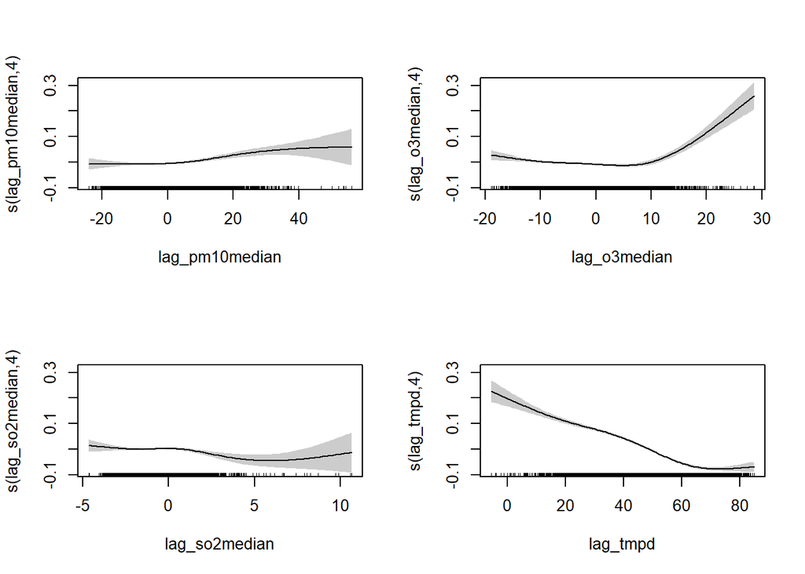

Partial effect plots of our lagged GAM.

The effect of the partial response function can be roughly gauged by its flatness. It appears that PM and SO2 do not have much of an effect on mortality. Temperature is not a pollutant, so we can deduce that the pollutant most associated with mortality is O3.

We also use a bootstrap to construct another $95\%$ pivotal confidence interval. Due to the model’s poor goodness-of-fit, we use the nonparametric resampling cases bootstrap, which does not assume model correctness. The resulting confidence interval is $[105.7958, 116.6299]$. (6)

The bootstrap confidence interval is wider than the model prediction confidence interval (a width of $10.8341$ versus $8.9945$) but the estimated values are very similar. We infer from the similarity that the model error does follow a $t_{n-q}$ distribution. (7) We will use the bootstrap confidence interval since it depends less on specific features of the empirical distribution of the data.

# Conclusions

By fitting and diagnosing several generalized additive models, we determined that there exists some non-zero association between pollutants and mortality. Our analysis showed that ozone was the pollutant most associated with mortality. Our model predicted that a 70-degree day in Chicago with pollutant levels matching the lowest recorded values would have an estimated mortality rate for that day of $[105.7958, 116.6299]$ on average.

Of course, we cannot conclude that this means ozone or any other variable causes deaths, we only concluded that some association exists. Our data is observational and our analysis is inferential, not causal. It’s more plausible that since temperature was more associated with mortality (consider deaths due to extreme heat or cold, such as the 1995 heat wave) and, as seen in the seasonal decomposition and pairs plots, ozone follows patterns highly similar to temperature, and thus ozone showed association with mortality. Therefore, though the analysis determined the existence of association, we cannot conclude that reducing pollutants would cause mortality to decrease due to the observational nature of the data.

One of the diagnostics of the model was its goodness of fit, which was found to be quite poor and that the variables provided to the model were insufficient. We can identify a number of limitations in the data, such as the lack of an exposure measurement: mortality is measured only as the number of “non-accidental” deaths per day and not to some relative metric such as total population or disease-related deaths. Further study to create a more accurate model for air pollution and mortality may use data from locations other than only Chicago, a city where homicide was reported to be the tenth leading cause of death in 2006.